# Practical Machine Learning Project

**Summary:** The aim of the project was to construct a machine learning algorithm which recognises which way (i.e. one ‘correct’ and 4 different ‘incorrect’ ways) barbell lifts excercises are performed. There was one variable (`classe`) which should be predicted and many, many possible predictors. Since there were almost 20k observations in the dataset I choose the simplest solution: to divide the data into 3 sets: training (60%), validation (20%) and test set (20%). I decided to check two algorithms: random forrest and SVM. They were trained on training dataset and checked on validation data. After this I concluded that random forrest should probably perform better slightly better on new data. This was confirmed on the test dataset.

*Disclaimer: Since I don’t know how to count words here and even which sets of characters should be counted as ‘words’ please don’t punish me if this report does not meet the required 2k words requirement. I try to give as little description as needed and most of the code is commented so it should not be hard to follow my actions.*

### Data reading

```r
library(caret)
library(randomForest)
library(ggplot2)
library(e1071) # for SVM

# reading data
df <- read.csv("../../data/pml-training.csv")
df <- df[,-1] # remove first column (row numbers)
dim(df)
```

```
## [1] 19622   159
```

As we can see there are almost 20k thousand records and 159 variables.

### Excluding data for final testing

```r
set.seed(10) # setting seed for replication

### divide data for training and testing
inTrain <- createDataPartition(y=df$classe, p=0.8, list=FALSE)
train1 <- df[as.vector(inTrain),] # used for training and validation
test <- df[-as.vector(inTrain),] # used only for final testing
```

For further analysis only `train1` data will be used.

### Cleaning the data

Firstly, after visual inspection of the data (I will spare the details) I concluded that there are many strange values (such as “#DIV/0!”), so I inspected factor variables with less than 10 levels.

```r
### data cleaning
# some factors should be numeric and some should probably be removed

# take all factor columns with levels less than 10
min.factors <- sapply(train1, function(x) length(levels(x))>0 & length(levels(x))<10)
summary(df[min.factors]) # no. 1, 2 and the last one should be left, the rest can be removed
```

```
##     user_name    new_window  kurtosis_yaw_belt skewness_yaw_belt
##  adelmo  :3892   no :19216          :19216            :19216
##  carlitos:3112   yes:  406   #DIV/0!:  406     #DIV/0!:  406
##  charles :3536
##  eurico  :3070
##  jeremy  :3402
##  pedro   :2610
##  amplitude_yaw_belt kurtosis_yaw_dumbbell skewness_yaw_dumbbell
##         :19216             :19216                :19216
##  #DIV/0!:   10      #DIV/0!:  406         #DIV/0!:  406
##  0.00   :   12
##  0.0000 :  384
##
##
##  amplitude_yaw_dumbbell kurtosis_yaw_forearm skewness_yaw_forearm
##         :19216                 :19216               :19216
##  #DIV/0!:    5          #DIV/0!:  406        #DIV/0!:  406
##  0.00   :  401
##
##
##
##  amplitude_yaw_forearm classe
##         :19216         A:5580
##  #DIV/0!:   84         B:3797
##  0.00   :  322         C:3422
##                        D:3216
##                        E:3607
##
```

And removed some of them:

```r
# remove columns with no values
rem1 <- which(min.factors)[-c(1,2,12)] # columns removed #1
train2 <- train1[-rem1]
```

After that I checked which of the factor variables should be numeric (sorry for the long result):

```r
# checking which variables should be numeric
all.factors <- sapply(train2, is.factor) # take all factor columns left
summary(train2[all.factors]) # 1,2,3 and last should stay as they are, the rest should be numeric
```

```
##     user_name             cvtd_timestamp new_window  kurtosis_roll_belt
##  adelmo  :3152   28/11/2011 14:14:1190   no :15371            :15371
##  carlitos:2478   05/12/2011 11:24:1175   yes:  328   #DIV/0!  :    8
##  charles :2825   05/12/2011 11:25:1149               -1.908453:    2
##  eurico  :2429   30/11/2011 17:11:1145               -0.016850:    1
##  jeremy  :2731   02/12/2011 13:34:1124               -0.021024:    1
##  pedro   :2084   02/12/2011 14:58:1115               -0.025513:    1
##                  (Other)         :8801               (Other)  :  315
##  kurtosis_picth_belt skewness_roll_belt skewness_roll_belt.1
##           :15371              :15371             :15371
##  #DIV/0!  :   25     #DIV/0!  :    7    #DIV/0!  :   25
##  47.000000:    4     0.000000 :    2    -3.072669:    3
##  -0.150950:    3     0.422463 :    2    6.855655 :    3
##  -1.750749:    3     -0.003095:    1    -0.189082:    2
##  -2.060105:    3     -0.010002:    1    -0.475418:    2
##  (Other)  :  290     (Other)  :  315    (Other)  :  293
##   max_yaw_belt    min_yaw_belt   kurtosis_roll_arm kurtosis_picth_arm
##         :15371          :15371           :15371            :15371
##  -1.4   :   25   -1.4   :   25   #DIV/0! :   70    #DIV/0! :   71
##  -1.1   :   22   -1.1   :   22   -0.02438:    1    -0.00484:    1
##  -0.9   :   20   -0.9   :   20   -0.04190:    1    -0.01311:    1
##  -1.2   :   19   -1.2   :   19   -0.05051:    1    -0.10385:    1
##  -1.5   :   16   -1.5   :   16   -0.05695:    1    -0.11279:    1
##  (Other):  226   (Other):  226   (Other) :  254    (Other) :  253
##  kurtosis_yaw_arm skewness_roll_arm skewness_pitch_arm skewness_yaw_arm
##          :15371           :15371            :15371             :15371
##  #DIV/0! :    8   #DIV/0! :   69    #DIV/0! :   71     #DIV/0! :    8
##  0.55844 :    2   -0.00051:    1    -0.00184:    1     0.55053 :    2
##  -0.01548:    1   -0.00696:    1    -0.01185:    1     -0.00311:    1
##  -0.01749:    1   -0.03359:    1    -0.01247:    1     -0.00562:    1
##  -0.02101:    1   -0.03484:    1    -0.02063:    1     -0.00800:    1
##  (Other) :  315   (Other) :  255    (Other) :  253     (Other) :  315
##  kurtosis_roll_dumbbell kurtosis_picth_dumbbell skewness_roll_dumbbell
##         :15371                 :15371                  :15371
##  #DIV/0!:    3          -0.0163:    1           -0.9324:    2
##  -0.2583:    2          -0.0233:    1           #DIV/0!:    2
##  -0.5855:    2          -0.0280:    1           0.1110 :    2
##  -0.0035:    1          -0.0308:    1           -0.0082:    1
##  -0.0073:    1          -0.0322:    1           -0.0172:    1
##  (Other):  319          (Other):  323           (Other):  320
```

[output cut: 9 more lines]

```
##         :15371                :15371                 :15371
##  #DIV/0!:   71         #DIV/0!:   72          #DIV/0!:   70
##  -0.8079:    2         -0.0073:    1          -0.1912:    2
##  -0.0227:    1         -0.0442:    1          -0.4126:    2
##  -0.0781:    1         -0.0489:    1          -0.0004:    1
##  -0.1363:    1         -0.0523:    1          -0.0013:    1
##  (Other):  252         (Other):  252          (Other):  252
##  skewness_pitch_forearm max_yaw_forearm min_yaw_forearm classe
##         :15371                 :15371          :15371   A:4464
##  #DIV/0!:   72          #DIV/0!:   71   #DIV/0!:   71   B:3038
##  0.0000 :    4          -1.2   :   27   -1.2   :   27   C:2738
##  -0.0131:    1          -1.3   :   24   -1.3   :   24   D:2573
##  -0.0405:    1          -1.4   :   19   -1.4   :   19   E:2886
##  -0.0478:    1          -1.6   :   19   -1.6   :   19
##  (Other):  249          (Other):  168   (Other):  168
```

And decided to take all but first three variables (and the last one of course) and converse them into numeric:

```r
# take indices of columns that should be numeric
f2num <- which(all.factors)[-c(1,2,3,sum(all.factors))]

# change factors to numbers
for(i in f2num){
    train2[,i] <- as.numeric(as.character(train2[,i]))
}
```

Then I checked how many complete data are in the dataset.

```r
# checking number of complete cases
sum(complete.cases(train2))
```

```
## [1] 169
```

Sometimes missing data can give some clue:

```r
# are classes dependant on complete cases?
table(train2[,150])
```

```
##
##    A    B    C    D    E
## 4464 3038 2738 2573 2886
```

```r
table(train2[complete.cases(train2),150]) # rather not
```

```
##
##  A  B  C  D  E
## 43 38 27 28 33
```

But not this time.

Let’s see which variables contain missing data:

```r
# how many missing values are in each column
as.data.frame(sapply(train1, function(x) sum(is.na(x)))) # looks like most of the values won't be helpful
```

[output not shown]

[output cut: 105 more lines]

```
## stddev_pitch_forearm                                         15371
## var_pitch_forearm                                            15371
## avg_yaw_forearm                                              15371
## stddev_yaw_forearm                                           15371
## var_yaw_forearm                                              15371
## gyros_forearm_x                                                  0
## gyros_forearm_y                                                  0
## gyros_forearm_z                                                  0
## accel_forearm_x                                                  0
## accel_forearm_y                                                  0
## accel_forearm_z                                                  0
## magnet_forearm_x                                                 0
## magnet_forearm_y                                                 0
## magnet_forearm_z                                                 0
## classe                                                           0
```

It looks like many variables can be removed.

```r
most.na <- sapply(train2, function(x) sum(is.na(x))>1)
rem2 <- which(most.na) # columns removed #2
train3 <- train2[-rem2]
sum(complete.cases(train3)) # all data are complete
```

```
## [1] 15699
```

The last thing was to remove 6 first variables which (after visual inspection) should not be considered as proper predictors.

```r
# removing first 6 columns which are not important
rem3 <- 1:6
train4 <- train3[-rem3]
```

### Train and validation set

The dataset was then divided into two sets: `train` (75% of the `train1` dataset so it gives 60% of the original dataset) and `valid`.

```r
### divide training data for model training and validation
inTrain2 <- createDataPartition(y=train4$classe, p=0.75, list=FALSE) # p==0.75 because only 80% of the original data were left
train <- train4[as.vector(inTrain2),] # used for training
valid <- train4[-as.vector(inTrain2),] # used for validation
```

### Random forrest

First model tested was random forest with default settings. At first I considered **caret** library for this but it took more than 2 hours to converge so for this report I used basic function in the **randomForest** library.

```r
### random forest
model1 <- randomForest(classe ~., data=train, importance=TRUE)
model1
```

```
##
## Call:
##  randomForest(formula = classe ~ ., data = train, importance = TRUE)
##                Type of random forest: classification
##                      Number of trees: 500
## No. of variables tried at each split: 7
##
##         OOB estimate of  error rate: 0.73%
## Confusion matrix:
##      A    B    C    D    E class.error
## A 3344    2    1    1    0 0.001194743
## B   17 2256    6    0    0 0.010092146
## C    0   15 2035    4    0 0.009250243
## D    0    0   27 1901    2 0.015025907
## E    0    0    4    7 2154 0.005080831
```

The results on the training set are pretty impressive. Random forest allows to see which predictors are most important, so let’s see:

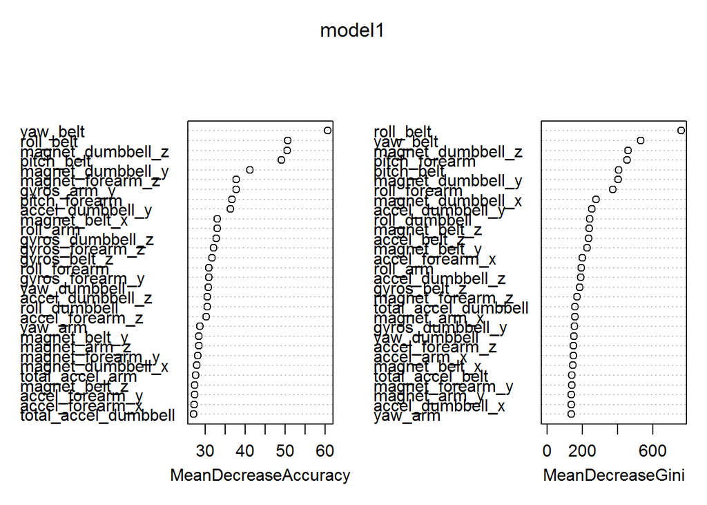

```r
varImpPlot(model1)
```

The most important variables are `yaw_belt` and `roll_belt` (no idea what it means). Let’s see these two variables on the plot:

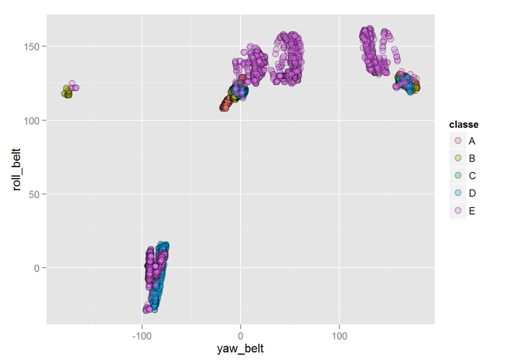

```r
qplot(yaw_belt, roll_belt, data=train, fill=classe, shape=I(21), size=I(3), alpha=I(0.3))
```

Looks interesting.

Now let’s take some of the least important variable and see if there are differences between these two plots:

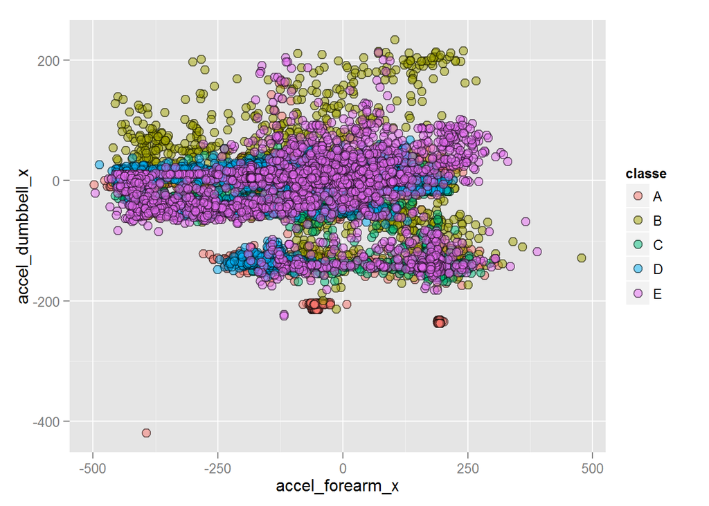

```r
qplot(accel_forearm_x, accel_dumbbell_x, data=train, fill=classe, shape=I(21), size=I(3), alpha=I(0.5))
```

Well, there are. The second plot is much more ‘messy’.

OK, let’s check how this model performs on validation data:

```r
y1 <- predict(model1, newdata=valid)
confusionMatrix(y1, valid$classe)
```

```
## Confusion Matrix and Statistics
##
##           Reference
## Prediction    A    B    C    D    E
##          A 1116    9    0    0    0
##          B    0  748    7    0    0
##          C    0    2  677    4    0
##          D    0    0    0  637    2
##          E    0    0    0    2  719
##
## Overall Statistics
##
##                Accuracy : 0.9934
##                  95% CI : (0.9903, 0.9957)
##     No Information Rate : 0.2845
##     P-Value [Acc > NIR] : < 2.2e-16
##
##                   Kappa : 0.9916
##  Mcnemar's Test P-Value : NA
##
## Statistics by Class:
##
##                      Class: A Class: B Class: C Class: D Class: E
## Sensitivity            1.0000   0.9855   0.9898   0.9907   0.9972
## Specificity            0.9968   0.9978   0.9981   0.9994   0.9994
## Pos Pred Value         0.9920   0.9907   0.9912   0.9969   0.9972
## Neg Pred Value         1.0000   0.9965   0.9978   0.9982   0.9994
## Prevalence             0.2845   0.1935   0.1744   0.1639   0.1838
## Detection Rate         0.2845   0.1907   0.1726   0.1624   0.1833
## Detection Prevalence   0.2868   0.1925   0.1741   0.1629   0.1838
## Balanced Accuracy      0.9984   0.9916   0.9940   0.9950   0.9983
```

Looks very promissing, its accuracy is more than 99%.

### SVM

The second algorithm I tried was SVM. I have to confess that I made some earlier calculation and used function `tune()` to find the parameters which should give nice results.

```r
### support vector machines
# I've made some preliminary testing to choose the best combinaation of parameters
model2 <- svm(classe~., data=train, kernel="polynomial", cost=100, degree=4, scale=F, probability=TRUE)
confusionMatrix(model2$fitted, train$classe)
```

```
## Confusion Matrix and Statistics
##
##           Reference
## Prediction    A    B    C    D    E
##          A 3348    0    0    0    0
##          B    0 2279    0    0    0
##          C    0    0 2054    0    0
##          D    0    0    0 1930    0
##          E    0    0    0    0 2165
##
## Overall Statistics
##
##                Accuracy : 1
##                  95% CI : (0.9997, 1)
##     No Information Rate : 0.2843
##     P-Value [Acc > NIR] : < 2.2e-16
##
##                   Kappa : 1
##  Mcnemar's Test P-Value : NA
##
## Statistics by Class:
##
##                      Class: A Class: B Class: C Class: D Class: E
## Sensitivity            1.0000   1.0000   1.0000   1.0000   1.0000
## Specificity            1.0000   1.0000   1.0000   1.0000   1.0000
## Pos Pred Value         1.0000   1.0000   1.0000   1.0000   1.0000
## Neg Pred Value         1.0000   1.0000   1.0000   1.0000   1.0000
## Prevalence             0.2843   0.1935   0.1744   0.1639   0.1838
## Detection Rate         0.2843   0.1935   0.1744   0.1639   0.1838
## Detection Prevalence   0.2843   0.1935   0.1744   0.1639   0.1838
## Balanced Accuracy      1.0000   1.0000   1.0000   1.0000   1.0000
```

And the results are indeed spectacular: no mistakes on training data.

What about validation dataset?

```r
y2 <- predict(model2, newdata=valid, probability=TRUE)
confusionMatrix(y2, valid$classe)
```

```
## Confusion Matrix and Statistics
##
##           Reference
## Prediction    A    B    C    D    E
##          A 1113    8    0    0    0
##          B    3  746    6    0    1
##          C    0    2  672   11    0
##          D    0    0    4  624    4
##          E    0    3    2    8  716
##
## Overall Statistics
##
##                Accuracy : 0.9867
##                  95% CI : (0.9827, 0.9901)
##     No Information Rate : 0.2845
##     P-Value [Acc > NIR] : < 2.2e-16
##
##                   Kappa : 0.9832
##  Mcnemar's Test P-Value : NA
##
## Statistics by Class:
##
##                      Class: A Class: B Class: C Class: D Class: E
## Sensitivity            0.9973   0.9829   0.9825   0.9705   0.9931
## Specificity            0.9971   0.9968   0.9960   0.9976   0.9959
## Pos Pred Value         0.9929   0.9868   0.9810   0.9873   0.9822
## Neg Pred Value         0.9989   0.9959   0.9963   0.9942   0.9984
## Prevalence             0.2845   0.1935   0.1744   0.1639   0.1838
## Detection Rate         0.2837   0.1902   0.1713   0.1591   0.1825
## Detection Prevalence   0.2858   0.1927   0.1746   0.1611   0.1858
## Balanced Accuracy      0.9972   0.9899   0.9892   0.9840   0.9945
```

Not bad at at all, but there are some mistakes. And overall the accuracy of the second model is a little worse than the first one.

**Conclusion:** Random forest model should perform better if new data appear.

### Model testing

Lucky me, I have some new data. Now it is time to use the `test` dataset which was excluded in the beginning.

We should not forget that many variables were removed in the training dataset. If we want to use this new data we have to perform the same operations:

```r
# repeating the 'data cleaning' operations
test1 <- test[-rem1]
for(i in f2num){
    test1[,i] <- as.numeric(as.character(test1[,i]))
}
test1 <- test1[-rem2]
test1 <- test1[-rem3]
```

Prediction results for model1 (RF):

```r
# testing model1 (RF)
z1 <- predict(model1, newdata=test1)
confusionMatrix(z1, test1$classe)
```

```
## Confusion Matrix and Statistics
##
##           Reference
## Prediction    A    B    C    D    E
##          A 1116    2    0    0    0
##          B    0  755    6    0    0
##          C    0    2  677    5    0
##          D    0    0    1  638    1
##          E    0    0    0    0  720
##
## Overall Statistics
##
##                Accuracy : 0.9957
##                  95% CI : (0.9931, 0.9975)
##     No Information Rate : 0.2845
##     P-Value [Acc > NIR] : < 2.2e-16
##
##                   Kappa : 0.9945
##  Mcnemar's Test P-Value : NA
##
## Statistics by Class:
##
##                      Class: A Class: B Class: C Class: D Class: E
## Sensitivity            1.0000   0.9947   0.9898   0.9922   0.9986
## Specificity            0.9993   0.9981   0.9978   0.9994   1.0000
## Pos Pred Value         0.9982   0.9921   0.9898   0.9969   1.0000
## Neg Pred Value         1.0000   0.9987   0.9978   0.9985   0.9997
## Prevalence             0.2845   0.1935   0.1744   0.1639   0.1838
## Detection Rate         0.2845   0.1925   0.1726   0.1626   0.1835
## Detection Prevalence   0.2850   0.1940   0.1744   0.1631   0.1835
## Balanced Accuracy      0.9996   0.9964   0.9938   0.9958   0.9993
```

Prediction results for model2 (SVM):

```r
# testing model2 (SVM)
z2 <- predict(model2, newdata=test1)
confusionMatrix(z2, test1$classe)
```

```
## Confusion Matrix and Statistics
##
##           Reference
## Prediction    A    B    C    D    E
##          A 1112    5    0    0    0
##          B    4  749    7    0    4
##          C    0    3  672    5    3
##          D    0    1    5  637    2
##          E    0    1    0    1  712
##
## Overall Statistics
##
##                Accuracy : 0.9895
##                  95% CI : (0.9858, 0.9925)
##     No Information Rate : 0.2845
##     P-Value [Acc > NIR] : < 2.2e-16
##
##                   Kappa : 0.9868
##  Mcnemar's Test P-Value : NA
##
## Statistics by Class:
##
##                      Class: A Class: B Class: C Class: D Class: E
## Sensitivity            0.9964   0.9868   0.9825   0.9907   0.9875
## Specificity            0.9982   0.9953   0.9966   0.9976   0.9994
## Pos Pred Value         0.9955   0.9804   0.9839   0.9876   0.9972
## Neg Pred Value         0.9986   0.9968   0.9963   0.9982   0.9972
## Prevalence             0.2845   0.1935   0.1744   0.1639   0.1838
## Detection Rate         0.2835   0.1909   0.1713   0.1624   0.1815
## Detection Prevalence   0.2847   0.1947   0.1741   0.1644   0.1820
## Balanced Accuracy      0.9973   0.9910   0.9895   0.9941   0.9934
```

The first model is slightly better. Additionally each correct excercises (‘A’) were classified correctly here. But to be honest, in my opinion both models perform extremely good on this data.